# Capstone Luis Lopez Guardado

```python
import glob
import csv
import os
import pandas as pd
from pandas.plotting import register_matplotlib_converters
import numpy as np
from datetime import datetime
import time
import traceback
import matplotlib.pyplot as plt
import matplotlib.dates as mdates
import seaborn as sns
sns.set()
import Capstone_Auxiliary_Functions as caf
import Capstone_Useful_Functions as cuf
from sklearn.model_selection import train_test_split,TimeSeriesSplit
from sklearn.linear_model import LinearRegression,SGDRegressor
```

## List of paths to csv files (source folder of data)

Paths to discharged csv's

```python
# Origin of prices nodes (not used)
Opath_PML_2018=glob.glob("C:/Users/U254524/Documents/Capstone local files/Original CSV inputs/2018 PMLs/*.csv")
Opath_PML_2019=glob.glob("C:/Users/U254524/Documents/Capstone local files/Original CSV inputs/2019 PMLs/*.csv")

#origin of prices regions
Opath_PND_2018=glob.glob("C:/Users/U254524/Documents/Capstone local files/Original CSV inputs/2018 PNDs/*.csv")
Opath_PND_2019=glob.glob("C:/Users/U254524/Documents/Capstone local files/Original CSV inputs/2019 PNDs/*.csv")

#origin of demands regions
Opath_Demand_2018=glob.glob("C:/Users/U254524/Documents/Capstone local files/Original CSV inputs/2018 Demands/*.csv")
Opath_Demand_2019=glob.glob("C:/Users/U254524/Documents/Capstone local files/Original CSV inputs/2019 Demands/*.csv")

#origin of commodities
Opath_commodities= glob.glob("C:/Users/U254524/Documents/Capstone local files/Test Original CSV inputs/Commodities/*.csv")

#origin of generation technologies
Opath_L0_Gen=glob.glob("C:/Users/U254524/Documents/Capstone local files/Generation CSV/L0/*.csv")
Opath_L1_Gen=glob.glob("C:/Users/U254524/Documents/Capstone local files/Generation CSV/L1/*.csv")
Opath_L2_Gen=glob.glob("C:/Users/U254524/Documents/Capstone local files/Generation CSV/L2/*.csv")
Opath_L3_Gen=glob.glob("C:/Users/U254524/Documents/Capstone local files/Generation CSV/L3/*.csv")
Opath_L4_Gen=glob.glob("C:/Users/U254524/Documents/Capstone local files/Generation CSV/L4/*.csv")

Opath_total_Gen = [Opath_L0_Gen,Opath_L1_Gen,Opath_L2_Gen,Opath_L3_Gen,Opath_L4_Gen]
Opath_total = [Opath_PND_2018,Opath_PND_2019,Opath_Demand_2018,Opath_Demand_2019]
```

## List of paths to csv files (destination folder of data)

Paths to saved dataframes csv's

```python
# Prices (nodes) (Not used)
Dpath_PML_2018='C:/Users/U254524/Documents/Capstone local files/Created inputs/2018 PMLs'
Dpath_PML_2019='C:/Users/U254524/Documents/Capstone local files/Created inputs/2019 PMLs'
# Prices (regions)
Dpath_PND_2018='C:/Users/U254524/Documents/Capstone local files/Created inputs/2018 PNDs'
Dpath_PND_2019='C:/Users/U254524/Documents/Capstone local files/Created inputs/2019 PNDs'
# Demands (regions)
Dpath_Demand_2018='C:/Users/U254524/Documents/Capstone local files/Created inputs/2018 Demands'
Dpath_Demand_2019='C:/Users/U254524/Documents/Capstone local files/Created inputs/2019 Demands'
# Destination of generation technologies (whole system)
Dpath_L0_Gen='C:/Users/U254524/Documents/Capstone local files/Created Generation inputs/L0'
Dpath_L1_Gen='C:/Users/U254524/Documents/Capstone local files/Created Generation inputs/L1'
Dpath_L2_Gen='C:/Users/U254524/Documents/Capstone local files/Created Generation inputs/L2'
Dpath_L3_Gen='C:/Users/U254524/Documents/Capstone local files/Created Generation inputs/L3'
Dpath_L4_Gen='C:/Users/U254524/Documents/Capstone local files/Created Generation inputs/L4'

Dpath_total_Gen = [Dpath_L0_Gen,Dpath_L1_Gen,Dpath_L2_Gen,Dpath_L3_Gen,Dpath_L4_Gen]
Dpath_total = [Dpath_PND_2018,Dpath_PND_2019,Dpath_Demand_2018,Dpath_Demand_2019]
```

## List of paths to csv file with complete saved information (destination folder of data)

```python
Final_CSV_path="C:/Users/U254524/Documents/Capstone local files/Final CSV"
Final_CSV_file=glob.glob("C:/Users/U254524/Documents/Capstone local files/Final CSV/*.csv")
```

## Path to csv with all csv file names loaded on the dataframe

```python
Dpath_csv_loaded='C:/Users/U254524/Documents/Capstone local files/Created inputs'
csv_loaded=Dpath_csv_loaded+'/data_included.csv' # Includes prices and demands list of csv files

Dpath_csv_Gen_loaded='C:/Users/U254524/Documents/Capstone local files/Created Generation inputs'
csv_loaded=Dpath_csv_Gen_loaded+'/data_included.csv' # Includes generation list of csv files
```

## Creation of new csv files to be included on the complete dataframe

```python
newfiles_list=caf.newfiles_list(Opath_total,Dpath_total,Dpath_csv_loaded) # Creates list of prices and demands files not included before
```

```
Reading files of csv already included in data
There is not a previous file created

List of files created
```

[output not shown]

```python
newfiles_list_Gen=caf.newfiles_list(Opath_total_Gen,Dpath_total_Gen,Dpath_csv_Gen_loaded)  # Creates list of new generation files not included before
```

```
Reading files of csv already included in data
There is not a previous file created

List of files created
```

[output not shown]

```python
newfiles_list
```

[output not shown]

[output cut: 3933 more lines]

[output not shown]

```python
newfiles_list_Gen
```

```
[['C:/Users/U254524/Documents/Capstone local files/Generation CSV/L0\\Generacion Liquidada_L0 SEN octubre 2019 v2019 11 14_05 00 01.csv',
  'C:/Users/U254524/Documents/Capstone local files/Generation CSV/L0\\Generacion Liquidada_L0 SEN septiembre 2019 v2019 10 14_05 00 01.csv'],
 ['C:/Users/U254524/Documents/Capstone local files/Generation CSV/L1\\Generacion Liquidada_L1 SEN agosto 2019 v2019 10 26_05 05 01.csv'],
 ['C:/Users/U254524/Documents/Capstone local files/Generation CSV/L2\\Generacion Liquidada_L2 SEN mayo 2019 v2019 09 20_05 10 01.csv',
  'C:/Users/U254524/Documents/Capstone local files/Generation CSV/L2\\Generacion Liquidada_L2 SEN abril 2019 v2019 08 20_05 10 01.csv',
  'C:/Users/U254524/Documents/Capstone local files/Generation CSV/L2\\Generacion Liquidada_L2 SEN julio 2019 v2019 11 20_05 10 01.csv',
  'C:/Users/U254524/Documents/Capstone local files/Generation CSV/L2\\Generacion Liquidada_L2 SEN junio 2019 v2019 10 20_05 10 01.csv'],
 ['C:/Users/U254524/Documents/Capstone local files/Generation CSV/L3\\Generacion Liquidada_L3 SEN diciembre 2018 v2019 08 05_05 15 01.csv',
  'C:/Users/U254524/Documents/Capstone local files/Generation CSV/L3\\Generacion Liquidada_L3 SEN mayo 2018 v2019 04 08_16 57 05.csv',
  'C:/Users/U254524/Documents/Capstone local files/Generation CSV/L3\\Generacion Liquidada_L3 SEN agosto 2018 v2019 04 08_16 57 38.csv',
  'C:/Users/U254524/Documents/Capstone local files/Generation CSV/L3\\Generacion Liquidada_L3 SEN febrero 2018 v2019 04 08_16 56 35.csv',
  'C:/Users/U254524/Documents/Capstone local files/Generation CSV/L3\\Generacion Liquidada_L3 SEN octubre 2018 v2019 06 05_05 15 01.csv',
  'C:/Users/U254524/Documents/Capstone local files/Generation CSV/L3\\Generacion Liquidada_L3 SEN febrero 2019 v2019 10 03_05 15 01.csv',
  'C:/Users/U254524/Documents/Capstone local files/Generation CSV/L3\\Generacion Liquidada_L3 SEN enero 2018 v2019 04 08_16 56 25.csv',
  'C:/Users/U254524/Documents/Capstone local files/Generation CSV/L3\\Generacion Liquidada_L3 SEN noviembre 2018 v2019 07 05_05 15 01.csv',
  'C:/Users/U254524/Documents/Capstone local files/Generation CSV/L3\\Generacion Liquidada_L3 SEN abril 2018 v2019 04 08_16 56 55.csv',
  'C:/Users/U254524/Documents/Capstone local files/Generation CSV/L3\\Generacion Liquidada_L3 SEN marzo 2019 v2019 11 03_05 15 01.csv',
  'C:/Users/U254524/Documents/Capstone local files/Generation CSV/L3\\Generacion Liquidada_L3 SEN septiembre 2018 v2019 05 05_05 15 01.csv',
  'C:/Users/U254524/Documents/Capstone local files/Generation CSV/L3\\Generacion Liquidada_L3 SEN julio 2018 v2019 04 08_16 57 27.csv',
  'C:/Users/U254524/Documents/Capstone local files/Generation CSV/L3\\Generacion Liquidada_L3 SEN junio 2018 v2019 04 08_16 57 16.csv',
  'C:/Users/U254524/Documents/Capstone local files/Generation CSV/L3\\Generacion Liquidada_L3 SEN enero 2019 v2019 09 05_05 15 01.csv',
  'C:/Users/U254524/Documents/Capstone local files/Generation CSV/L3\\Generacion Liquidada_L3 SEN marzo 2018 v2019 04 08_16 56 45.csv'],
 ['C:/Users/U254524/Documents/Capstone local files/Generation CSV/L4\\Generacion Liquidada_L4 SEN septiembre 2018 v2019 11 12_05 17 01.csv',
  'C:/Users/U254524/Documents/Capstone local files/Generation CSV/L4\\Generacion Liquidada_L4 SEN agosto 2018 v2019 09 30_05 17 01.csv',
  'C:/Users/U254524/Documents/Capstone local files/Generation CSV/L4\\Generacion Liquidada_L4 SEN octubre 2018 v2019 11 23_05 17 01.csv',
  'C:/Users/U254524/Documents/Capstone local files/Generation CSV/L4\\Generacion Liquidada_L4 SEN junio 2018 v2019 07 25_05 17 01.csv',
  'C:/Users/U254524/Documents/Capstone local files/Generation CSV/L4\\Generacion Liquidada_L4 SEN febrero 2018 v2019 04 11_05 17 01.csv',
  'C:/Users/U254524/Documents/Capstone local files/Generation CSV/L4\\Generacion Liquidada_L4 SEN julio 2018 v2019 08 12_05 17 01.csv',
  'C:/Users/U254524/Documents/Capstone local files/Generation CSV/L4\\Generacion Liquidada_L4 SEN marzo 2018 v2019 05 13_05 17 01.csv',
  'C:/Users/U254524/Documents/Capstone local files/Generation CSV/L4\\Generacion Liquidada_L4 SEN enero 2018 v2019 04 08_16 27 05.csv',
  'C:/Users/U254524/Documents/Capstone local files/Generation CSV/L4\\Generacion Liquidada_L4 SEN abril 2018 v2019 06 11_05 17 01.csv',
  'C:/Users/U254524/Documents/Capstone local files/Generation CSV/L4\\Generacion Liquidada_L4 SEN mayo 2018 v2019 07 06_05 17 01.csv']]
```

## Reading of csv and list of created dataframes

### Examples of created df structure depending on type of csv

```python
dfdemands=caf.read_n_create_files('C:/Users/U254524/Documents/Capstone local files/Test Original CSV inputs/2019 Demands\\CantAsigEnerElecZonCarMDA BCA MDA Dia 2019-01-01 v2018 12 31_12 03 37.csv')
dfpmls=caf.read_n_create_files('C:/Users/U254524/Documents/Capstone local files/Test Original CSV inputs/2018 PMLs\\5_31-12-2017_16-49-46_BCA_PreciosMargLocalesMDA.csv')
dfpnds=caf.read_n_create_files('C:/Users/U254524/Documents/Capstone local files/Test Original CSV inputs/2019 PNDs\\26_31-12-2018_12-03-37_BCA_PreciosNodosDistribuidosMDA.csv')

dfcommodities=caf.read_commodities(Opath_commodities[0])

dfgeneration=caf.read_n_create_generation('C:/Users/U254524/Documents/Capstone local files/Generation CSV/L0/Generacion Liquidada_L0 SEN octubre 2019 v2019 11 14_05 00 01.csv')
```

```python
dfdemands.head()
```

|  | Fecha | Fecha_completa | Día | Mes | Año | Hora | Minuto | Nodo o Region | Demanda total (MWh) | Demanda D. mod (MWh) | Demanda I. mod (MWh) |
| --- | --- | --- | --- | --- | --- | --- | --- | --- | --- | --- | --- |
| 0 | 2019-01-01 | 2019-01-01 00:00:00 | 1 | 1 | 2019 | 1 | 0 | ENSENADA | 129.130 | 0.06 | 129.070 |
| 1 | 2019-01-01 | 2019-01-01 01:00:00 | 1 | 1 | 2019 | 2 | 0 | ENSENADA | 124.699 | 0.06 | 124.639 |
| 2 | 2019-01-01 | 2019-01-01 02:00:00 | 1 | 1 | 2019 | 3 | 0 | ENSENADA | 119.451 | 0.06 | 119.391 |
| 3 | 2019-01-01 | 2019-01-01 03:00:00 | 1 | 1 | 2019 | 4 | 0 | ENSENADA | 114.336 | 0.06 | 114.276 |
| 4 | 2019-01-01 | 2019-01-01 04:00:00 | 1 | 1 | 2019 | 5 | 0 | ENSENADA | 111.655 | 0.06 | 111.595 |

```python
dfpmls.head()  #(Not used)
```

|  | Fecha | Fecha_completa | Día | Mes | Año | Hora | Minuto | Nodo o Region | Precio | Componente de energia ($/MWh) | Componente de perdidas ($/MWh) | Componente de congestion ($/MWh) |
| --- | --- | --- | --- | --- | --- | --- | --- | --- | --- | --- | --- | --- |
| 0 | 2018-01-01 | 2018-01-01 00:00:00 | 1 | 1 | 2018 | 1 | 0 | 07ACU-115 | 188.14 | 187.15 | 0.99 | 0 |
| 1 | 2018-01-01 | 2018-01-01 01:00:00 | 1 | 1 | 2018 | 2 | 0 | 07ACU-115 | 802.50 | 799.03 | 3.47 | 0 |
| 2 | 2018-01-01 | 2018-01-01 02:00:00 | 1 | 1 | 2018 | 3 | 0 | 07ACU-115 | 783.71 | 780.70 | 3.02 | 0 |
| 3 | 2018-01-01 | 2018-01-01 03:00:00 | 1 | 1 | 2018 | 4 | 0 | 07ACU-115 | 813.27 | 810.53 | 2.74 | 0 |
| 4 | 2018-01-01 | 2018-01-01 04:00:00 | 1 | 1 | 2018 | 5 | 0 | 07ACU-115 | 499.15 | 497.33 | 1.82 | 0 |

```python
dfpnds.head()
```

|  | Fecha | Fecha_completa | Día | Mes | Año | Hora | Minuto | Nodo o Region | Precio | Componente de energia ($/MWh) | Componente de perdidas ($/MWh) | Componente de congestion ($/MWh) |
| --- | --- | --- | --- | --- | --- | --- | --- | --- | --- | --- | --- | --- |
| 0 | 2019-01-01 | 2019-01-01 00:00:00 | 1 | 1 | 2019 | 1 | 0 | ENSENADA | 293.43 | 285.72 | 7.72 | 0 |
| 1 | 2019-01-01 | 2019-01-01 01:00:00 | 1 | 1 | 2019 | 2 | 0 | ENSENADA | 308.92 | 300.44 | 8.49 | 0 |
| 2 | 2019-01-01 | 2019-01-01 02:00:00 | 1 | 1 | 2019 | 3 | 0 | ENSENADA | 268.81 | 262.36 | 6.44 | 0 |
| 3 | 2019-01-01 | 2019-01-01 03:00:00 | 1 | 1 | 2019 | 4 | 0 | ENSENADA | 273.64 | 267.20 | 6.43 | 0 |
| 4 | 2019-01-01 | 2019-01-01 04:00:00 | 1 | 1 | 2019 | 5 | 0 | ENSENADA | 308.01 | 300.92 | 7.09 | 0 |

```python
dfcommodities.head()
```

|  | Fecha | Día | Mes | Año | TdC | API2 | Brent | HH |
| --- | --- | --- | --- | --- | --- | --- | --- | --- |
| 0 | 2018-01-01 | 1 | 1 | 2018 | 23.66 | 95.60 | 66.54 | 2.96 |
| 1 | 2018-01-02 | 2 | 1 | 2018 | 23.55 | 95.70 | 66.60 | 7.13 |
| 2 | 2018-01-03 | 3 | 1 | 2018 | 23.38 | 95.05 | 68.07 | 6.80 |
| 3 | 2018-01-04 | 4 | 1 | 2018 | 23.32 | 94.60 | 68.72 | 4.38 |
| 4 | 2018-01-05 | 5 | 1 | 2018 | 23.33 | 95.00 | 68.17 | 2.93 |

```python
dfgeneration.head()
```

|  | Fecha | Día | Mes | Año | Hora | Eolica | Fotovoltaica | Biomasa | Carboelectrica | Ciclo Combinado | Combustion Interna | Geotermoelectrica | Hidroelectrica | Nucleoelectrica | Termica Convencional | Turbo Gas |
| --- | --- | --- | --- | --- | --- | --- | --- | --- | --- | --- | --- | --- | --- | --- | --- | --- |
| 0 | 2019-10-01 | 1 | 10 | 2019 | 1 | 1597.3661 | 0.013 | 4.0755 | 1926.4997 | 22350.1867 | 386.9935 | 434.0642 | 1987.9591 | 1501.7590 | 3797.4511 | 2060.1337 |
| 1 | 2019-10-01 | 1 | 10 | 2019 | 2 | 1765.7840 | 0.013 | 4.0711 | 1731.6396 | 21598.6923 | 392.4398 | 434.8160 | 1611.7873 | 1516.3310 | 3643.0484 | 1886.2219 |
| 2 | 2019-10-01 | 1 | 10 | 2019 | 3 | 1802.0870 | 0.000 | 4.0738 | 1884.7242 | 20992.9326 | 390.1613 | 459.8841 | 1428.6484 | 1522.6016 | 3361.8122 | 1728.8118 |
| 3 | 2019-10-01 | 1 | 10 | 2019 | 4 | 1721.1077 | 0.000 | 4.0762 | 1807.9557 | 20513.3185 | 395.9127 | 464.8364 | 1470.6221 | 1524.3019 | 3321.8533 | 1711.0372 |
| 4 | 2019-10-01 | 1 | 10 | 2019 | 5 | 1378.3773 | 0.000 | 4.0717 | 1718.4077 | 20825.9122 | 390.9411 | 465.4951 | 1414.1501 | 1524.1717 | 3408.7735 | 1598.9155 |

## Creation of dataframes from each source

```python
list_of_df=[]
save_created_csv=True
for i in range(len(Dpath_total)):
    list_of_df.append(caf.create_or_load_dataframe(newfiles_list[i],Dpath_total[i],save_created_csv))
list_of_included_files=caf.create_newfiles_list_n_save(Opath_total,Dpath_total,Dpath_csv_loaded)
list_of_included_files
```

[output not shown]

[output cut: 16691 more lines]

[output not shown]

[output not shown]

1095 rows × 4 columns

```python
dfcommodities=caf.read_commodities(Opath_commodities[0])
```

```python
list_of_generation_df=[]
save_created_Gen_csv=True
for i in range(len(Dpath_total_Gen)):
    list_of_generation_df.append(caf.create_or_load_dataframe_generation(newfiles_list_Gen[i],Dpath_total_Gen[i],save_created_Gen_csv))
list_of_gen_included_files=caf.create_newfiles_list_n_save(Opath_total_Gen,Dpath_total_Gen,Dpath_csv_Gen_loaded)
list_of_gen_included_files
```

[output not shown]

[output cut: 126 more lines]

```
 file: C:/Users/U254524/Documents/Capstone local files/Generation CSV/L4\Generacion Liquidada_L4 SEN abril 2018 v2019 06 11_05 17 01.csv
Done

DataFrame nº 10 of a total of 10:
 file: C:/Users/U254524/Documents/Capstone local files/Generation CSV/L4\Generacion Liquidada_L4 SEN mayo 2018 v2019 07 06_05 17 01.csv
Done

Range of files from 1 to 10 ok

Wrong files:
 []
Creating a unique dataframe
Saving dataframe to destination csv:C:/Users/U254524/Documents/Capstone local files/Created Generation inputs/L4/Saved_data.csv
Updated CSV file created
 Process complete :-)
```

|  | L0 | L1 | L2 | L3 | L4 |
| --- | --- | --- | --- | --- | --- |
| 0 | C:/Users/U254524/Documents/Capstone local file... | C:/Users/U254524/Documents/Capstone local file... | C:/Users/U254524/Documents/Capstone local file... | C:/Users/U254524/Documents/Capstone local file... | C:/Users/U254524/Documents/Capstone local file... |
| 1 | C:/Users/U254524/Documents/Capstone local file... | NaN | C:/Users/U254524/Documents/Capstone local file... | C:/Users/U254524/Documents/Capstone local file... | C:/Users/U254524/Documents/Capstone local file... |
| 2 | NaN | NaN | C:/Users/U254524/Documents/Capstone local file... | C:/Users/U254524/Documents/Capstone local file... | C:/Users/U254524/Documents/Capstone local file... |
| 3 | NaN | NaN | C:/Users/U254524/Documents/Capstone local file... | C:/Users/U254524/Documents/Capstone local file... | C:/Users/U254524/Documents/Capstone local file... |
| 4 | NaN | NaN | NaN | C:/Users/U254524/Documents/Capstone local file... | C:/Users/U254524/Documents/Capstone local file... |
| 5 | NaN | NaN | NaN | C:/Users/U254524/Documents/Capstone local file... | C:/Users/U254524/Documents/Capstone local file... |
| 6 | NaN | NaN | NaN | C:/Users/U254524/Documents/Capstone local file... | C:/Users/U254524/Documents/Capstone local file... |
| 7 | NaN | NaN | NaN | C:/Users/U254524/Documents/Capstone local file... | C:/Users/U254524/Documents/Capstone local file... |
| 8 | NaN | NaN | NaN | C:/Users/U254524/Documents/Capstone local file... | C:/Users/U254524/Documents/Capstone local file... |
| 9 | NaN | NaN | NaN | C:/Users/U254524/Documents/Capstone local file... | C:/Users/U254524/Documents/Capstone local file... |
| 10 | NaN | NaN | NaN | C:/Users/U254524/Documents/Capstone local file... | NaN |
| 11 | NaN | NaN | NaN | C:/Users/U254524/Documents/Capstone local file... | NaN |
| 12 | NaN | NaN | NaN | C:/Users/U254524/Documents/Capstone local file... | NaN |
| 13 | NaN | NaN | NaN | C:/Users/U254524/Documents/Capstone local file... | NaN |
| 14 | NaN | NaN | NaN | C:/Users/U254524/Documents/Capstone local file... | NaN |

## Creation of complete datasets

```python
#df_total_PMLs=pd.concat([list_of_df[0],list_of_df[2]], ignore_index=True,sort=False)
df_total_PNDs=pd.concat([list_of_df[0],list_of_df[1]], ignore_index=True,sort=False)
df_total_Demands=pd.concat([list_of_df[2],list_of_df[3]], ignore_index=True,sort=False)
```

```python
df_total_generation=caf.merge_generation(list_of_generation_df)
```

```
Original dataframe shape 1465,
merged with a dataframe of shape 744
Expected merged shape should be 2209 and is 2209

We have added to the original dataframe of 1465, 744 new items from the merged dataframe

merged indicator column description

count          2209
unique            2
top       left_only
freq           1465
Name: _merge, dtype: object

0 Items in common with the last version of dataframe
<class 'pandas.core.frame.DataFrame'>
Int64Index: 2209 entries, 0 to 2208
Data columns (total 16 columns):
Fecha                   2209 non-null datetime64[ns]
Día                     2209 non-null int64
Mes                     2209 non-null int64
Año                     2209 non-null int64
Hora                    2209 non-null int64
Eolica                  2209 non-null float64
Fotovoltaica            2209 non-null float64
Biomasa                 2209 non-null float64
Carboelectrica          2209 non-null float64
Ciclo Combinado         2209 non-null float64
Combustion Interna      2209 non-null float64
Geotermoelectrica       2209 non-null float64
Hidroelectrica          2209 non-null float64
Nucleoelectrica         2209 non-null float64
Termica Convencional    2209 non-null float64
Turbo Gas               2209 non-null float64
dtypes: datetime64[ns](1), float64(11), int64(4)
memory usage: 293.4 KB

           Fecha  Día  Mes   Año  Hora     Eolica  Fotovoltaica  Biomasa  \
1465 2019-08-01    1    8  2019     1  3452.5369        0.0001   2.5255
1489 2019-08-02    2    8  2019     1  2720.5962        0.0001   2.4856
```

[output cut: 344 more lines]

```
min              0.000000         173.720800        0.000000         0.000000
25%            283.332450         552.391650     1622.497550      1380.094050
50%            328.380300         573.877400     2890.979100      1526.262100
75%            369.519200         601.702100     4655.523100      1549.183300
max            438.320600         661.257800    10018.415200      1585.567400

       Termica Convencional     Turbo Gas
count          16059.000000  16059.000000
mean            4650.130809   1771.542538
std             1276.812169    297.255552
min               37.090300      0.000000
25%             3661.598350   1568.938750
50%             4706.108200   1750.173600
75%             5697.249400   1947.714100
max             7428.946100   2787.717900
```

## Conclusions loading generation dataset

I have discharged and loaded all the files containing generation by technology These files are different from the file structure followed fot prices and demand Discharged files includes monthly files with detailed information for each hour of the day There are four versions of the published files. - L0 (original data) contains the original data publised on the 7 days after the day operation in the market - L1 (initial reliquidation) includes a more accurate information 49 days after the daily operation in the market (this information sustitutes the L0 information) - L2 (intermediate reliquidation) includes a more accurate information 105 days after the daily operation in the market (this information sustitutes the L0 and L1 information) - L3 (final reliquidation) includes a more accurate information 210 days after the daily operation in the market (this information sustitutes the L0, L1 and L2 information) - L4 (controversial reliquidation) only appears on the cases revised. I have discharged the latest available version of the file up to date and L4' version if available. And copied the files on their corresponding folder (Opath_LXX_Gen)

## Loading dataset generation process (Similar to the process to load prices and demands)

The process followed to load data is the following: - I have created a function that opens one of the csv file and read its contend. - The funcion creates a dataframe including the columns obtained from the dataframe (a little bit modified) - Also creates one column as datestime, very useful to locate specific data - Once the dataframe is created and filled in with data from the csv, it is appended as an element to a list of dataframes (LoDf) and I repeat the process for all the files included on the specific folder. - Once all the files of the folder have been treated, I use the pandas dataframe.concat method to all dataframes of the list of dataframes created and obtain a dataframe including all data of the specific folder and I append this final dataframe as an element to a list. -I repeat the process for each of the folders and obtains a list with a final dataframe per folder. To avoid reapeating this process everytime, I saved each element of the list (dataframes) on a csv file on the specified destination folder And also created a dataframe saved to a csv including all the treated files (columns = folder name and elements= file names) (I will refer later to this dataframe as preloaded list) Method followed to speed up data adquisition process: - Prior to the process explained above, I created a list including all the name of the files in each folder (actual list) - This list is compared with a previously generated list of files per folder (preloaded list) - If there is any new file present in the actual list that is not included on the preloaded list, this file is treated. - I load saved dataframe per folder (if exist) and uses it as first element of the dataframes list (LoDf), the new files are appended as new elements to this list - Later I concat all the elements of the Lodf (dataframes) and append it to a complete dataframe per folder that, as before explained is saved to a csv file - Dataframe containing file names per folder is updated to include new treated files. To create a final dataframe incluiding all the generation info, I have used the pandas dataframe merge method. To merge L0 to L3 dataframes, I have used the parameter how='outer' since there is no intersection between L0 to L3 datasets. As for merged dataframe (L0 to L3) and L4 dataframe I have used as parameter how='left' but only on on=['Fecha','Día','Mes','Año','Hora'] columns, since I do not want to include more elements to the rows, since total number of rows has to be equal to (nº of days+1) times 24 hours = 16059 values (from 1-1-18 to 31-10-19) this process created several additional columns, I created the original ones (without suffix) as a fillna method with the L4 dataframe I included a little test (modifying manually one input I confirmed that merged dataframe was updated). (I have realized after having prepared the model to update L0,L1,L2 and L3 data, that information published by Cenace as L4 has not changed information published on files L0 to L3, but it doesn't mean they could not change the information, and in that case, the model will reflect those changes in data) To finish the proces, I drop the suffixed columns.

## Creation of final Dataframe

```python
df=caf.merge_all(df_total_PNDs,df_total_Demands,dfcommodities,df_total_generation)
```

In this process: First I have discarted all the rows that do not have values on the prices and demands but have values on the commodities' dataframe (future values). Second, I have discarted all the rows that do not have values on the generation production by technology. In total I should have (1/1/18 to 31/10/19)=669 days times 108 regions times 24 = 1.734.048 rows less 4 (corresponding to th 4 regions of the division of Baja California (ie. ['ENSENADA','MEXICALI','SANLUIS','TIJUANA']) that have changed to the winter time (meaning 4 regions with 25 hours) in november 3rd. (The rest of regions changed time to winter time on 27/10/19 as shown below) I have also created three new columns with the commodities in pesos This yields to a total number of rows of 1.734.044

```python
df['Brent_pesos']=df['Brent']*df['TdC']
df['API2_pesos']=df['API2']*df['TdC']
df['HH_pesos']=df['HH']*df['TdC']
```

```python
print('Number of regions that changed to winter time in 2019 are: {}\nAnd the date when it occured was:{}'.format(df[df['Hora']==25]['Fecha'].count()-108,set(df[df['Hora']==25]['Fecha'])))
```

```
Number of regions that changed to winter time in 2019 are: 104
And the date when it occured was:{Timestamp('2018-10-28 00:00:00'), Timestamp('2019-10-27 00:00:00'), Timestamp('2018-11-04 00:00:00')}
```

```python
print(df.info(),'\n\n',df.isnull().sum(),'\n\nThis means there are not null values\n\ndf.head()\n',df.describe(),df.head())
```

```
<class 'pandas.core.frame.DataFrame'>
Int64Index: 1734044 entries, 248840 to 953851
Data columns (total 33 columns):
Fecha                               datetime64[ns]
Fecha_completa                      datetime64[ns]
Día                                 int64
Mes                                 int64
Año                                 int64
Hora                                float64
Minuto                              float64
Nodo o Region                       object
Precio                              float64
Componente de energia ($/MWh)       float64
Componente de perdidas ($/MWh)      float64
Componente de congestion ($/MWh)    float64
Demanda total (MWh)                 float64
Demanda D. mod (MWh)                float64
Demanda I. mod (MWh)                float64
TdC                                 float64
API2                                float64
Brent                               float64
HH                                  float64
Eolica                              float64
Fotovoltaica                        float64
Biomasa                             float64
Carboelectrica                      float64
Ciclo Combinado                     float64
Combustion Interna                  float64
Geotermoelectrica                   float64
Hidroelectrica                      float64
Nucleoelectrica                     float64
Termica Convencional                float64
Turbo Gas                           float64
Brent_pesos                         float64
API2_pesos                          float64
HH_pesos                            float64
dtypes: datetime64[ns](2), float64(27), int64(3), object(1)
memory usage: 449.8+ MB
None

```

[output cut: 129 more lines]

```
        Hidroelectrica  Nucleoelectrica  Termica Convencional  Turbo Gas  \
248840       1213.7404        1559.3556             2200.5833  1271.7775
248841       1213.7404        1559.3556             2200.5833  1271.7775
248842       1213.7404        1559.3556             2200.5833  1271.7775
248843       1213.7404        1559.3556             2200.5833  1271.7775
248844       1213.7404        1559.3556             2200.5833  1271.7775

        Brent_pesos  API2_pesos  HH_pesos
248840    1574.3364    2261.896   70.0336
248841    1574.3364    2261.896   70.0336
248842    1574.3364    2261.896   70.0336
248843    1574.3364    2261.896   70.0336
248844    1574.3364    2261.896   70.0336

[5 rows x 33 columns]
```

## Saving data to a final dataframe to avoid all the process above each time I run the program

```python
df.to_csv(Final_CSV_path+'/Saved_data.csv')
```

## Reading previously Final_CSV

```python
#I have repeated this code here in order to shorten the process of loading data.

import glob
import csv
import os
import pandas as pd
from pandas.plotting import register_matplotlib_converters
import numpy as np
from datetime import datetime
import time
import traceback
import matplotlib.pyplot as plt
import matplotlib.dates as mdates
import seaborn as sns
sns.set()
import Capstone_Auxiliary_Functions as caf
import Capstone_Useful_Functions as cuf
from sklearn.model_selection import train_test_split,TimeSeriesSplit
from sklearn.linear_model import LinearRegression,SGDRegressor


Final_CSV_path="C:/Users/U254524/Documents/Capstone local files/Final CSV"
Final_CSV_file=glob.glob("C:/Users/U254524/Documents/Capstone local files/Final CSV/*.csv")

df=caf.reading_csv(Final_CSV_path)
```

```
C:/Users/U254524/Documents/Capstone local files/Final CSV/Saved_data.csv
```

```python
print('For comparison purposes with df before saving and loading process I include this\n\n',df.shape,df.head(),df.info(),df.describe())
```

```
<class 'pandas.core.frame.DataFrame'>
Int64Index: 1734044 entries, 0 to 1734043
Data columns (total 33 columns):
Fecha                               datetime64[ns]
Fecha_completa                      datetime64[ns]
Día                                 int64
Mes                                 int64
Año                                 int64
Hora                                float64
Minuto                              float64
Nodo o Region                       object
Precio                              float64
Componente de energia ($/MWh)       float64
Componente de perdidas ($/MWh)      float64
Componente de congestion ($/MWh)    float64
Demanda total (MWh)                 float64
Demanda D. mod (MWh)                float64
Demanda I. mod (MWh)                float64
TdC                                 float64
API2                                float64
Brent                               float64
HH                                  float64
Eolica                              float64
Fotovoltaica                        float64
Biomasa                             float64
Carboelectrica                      float64
Ciclo Combinado                     float64
Combustion Interna                  float64
Geotermoelectrica                   float64
Hidroelectrica                      float64
Nucleoelectrica                     float64
Termica Convencional                float64
Turbo Gas                           float64
Brent_pesos                         float64
API2_pesos                          float64
HH_pesos                            float64
dtypes: datetime64[ns](2), float64(27), int64(3), object(1)
memory usage: 449.8+ MB
For comparison purposes with df before saving and loading process I include this

```

[output cut: 84 more lines]

```
50%            4.706215e+03  1.750247e+03  1.497911e+03  1.859256e+03
75%            5.697265e+03  1.947767e+03  1.629960e+03  2.131668e+03
max            7.428946e+03  2.787718e+03  1.887766e+03  2.374347e+03

           HH_pesos
count  1.734044e+06
mean   6.444345e+01
std    1.413875e+01
min    4.407640e+01
25%    5.569740e+01
50%    6.291000e+01
75%    6.810880e+01
max    1.679115e+02

[8 rows x 30 columns]
```

## Regions selection

```python
df.sort_values(by=['Fecha_completa'], ascending=True)[['Nodo o Region','Componente de energia ($/MWh)']]
#It seems that this value is similar for all the Sistema Interconectado Nacional regions, and different for Baja California and Baja California Sur
dfdivision=caf.group_by_division(df)
print(dfdivision)
# I mapped the regions to the divisions they are part of.
# Doing so, we can observe that this component is the same each hour for for all the regions except for those of Baja California and Baja California Sur
# Therefore I will drop this regions in order to have less variability on predictions
for i in ['ENSENADA','MEXICALI','SANLUIS','TIJUANA','CONSTITUCION','LA PAZ','LOS CABOS']:
    index_to_drop=df[df['Nodo o Region']==i].index
    df.drop(index_to_drop, inplace=True)
print(len(set(df['Nodo o Region'])))
```

```
             Fecha      Fecha_completa  Día  Mes   Año  Hora  Minuto  \
0       2018-01-01 2018-01-01 00:00:00    1    1  2018   1.0     0.0
1       2018-01-01 2018-01-01 00:00:00    1    1  2018   1.0     0.0
2       2018-01-01 2018-01-01 00:00:00    1    1  2018   1.0     0.0
3       2018-01-01 2018-01-01 00:00:00    1    1  2018   1.0     0.0
4       2018-01-01 2018-01-01 00:00:00    1    1  2018   1.0     0.0
5       2018-01-01 2018-01-01 00:00:00    1    1  2018   1.0     0.0
6       2018-01-01 2018-01-01 00:00:00    1    1  2018   1.0     0.0
7       2018-01-01 2018-01-01 00:00:00    1    1  2018   1.0     0.0
8       2018-01-01 2018-01-01 00:00:00    1    1  2018   1.0     0.0
9       2018-01-01 2018-01-01 00:00:00    1    1  2018   1.0     0.0
10      2018-01-01 2018-01-01 00:00:00    1    1  2018   1.0     0.0
11      2018-01-01 2018-01-01 00:00:00    1    1  2018   1.0     0.0
12      2018-01-01 2018-01-01 00:00:00    1    1  2018   1.0     0.0
13      2018-01-01 2018-01-01 00:00:00    1    1  2018   1.0     0.0
```

[output cut: 302 more lines]

## Price features selection

```python
df['Precioprima']=df['Componente de energia ($/MWh)']+df['Componente de perdidas ($/MWh)']+df['Componente de congestion ($/MWh)']
print(df[(df['Precio']-df['Precioprima'])>0.1])

''' This result confirms that these features are lineally correlated. I will therefore discard ['Precio','Componente de perdidas ($/MWh)' and 'Componente de congestion ($/MWh)']'''

df.drop(['Precioprima','Precio','Componente de perdidas ($/MWh)','Componente de congestion ($/MWh)'], axis=1, inplace=True)
```

```
Empty DataFrame
Columns: [Fecha, Fecha_completa, Día, Mes, Año, Hora, Minuto, Nodo o Region, Precio, Componente de energia ($/MWh), Componente de perdidas ($/MWh), Componente de congestion ($/MWh), Demanda total (MWh), Demanda D. mod (MWh), Demanda I. mod (MWh), TdC, API2, Brent, HH, Eolica, Fotovoltaica, Biomasa, …
Index: []

[0 rows x 34 columns]
```

## Demands selection

```python
df['Demandaprima']=df['Demanda I. mod (MWh)']+df['Demanda D. mod (MWh)']
print(df[(df['Demanda total (MWh)']-df['Demandaprima'])>0.1])

''' This result confirms that these features are lineally correlated. I will therefore discard ['Demanda D. mod (MWh)','Demanda I. mod (MWh)']'''

df.drop(['Demandaprima','Demanda D. mod (MWh)','Demanda I. mod (MWh)'], axis=1, inplace=True)
```

```
Empty DataFrame
Columns: [Fecha, Fecha_completa, Día, Mes, Año, Hora, Minuto, Nodo o Region, Componente de energia ($/MWh), Demanda total (MWh), Demanda D. mod (MWh), Demanda I. mod (MWh), TdC, API2, Brent, HH, Eolica, Fotovoltaica, Biomasa, Carboelectrica, Ciclo Combinado, Combustion Interna, Geotermoelectrica, Hi…
Index: []

[0 rows x 31 columns]
```

## Commodities selection

```python
''' Prices are given in pesos/MWh, therefore, it makes sense to keep only those commodities in pesos'''
df.drop(['TdC','Brent','HH','API2'], axis=1, inplace=True)
''' Nevertheless, since these are daily values and we have hourly data I will drop them also'''
df.drop(['Brent_pesos','HH_pesos','API2_pesos'], axis=1, inplace=True)
```

## Checking on aggregated hourly productions and aggregated houly Total demands

```python
df['Total_prod']=df['Eolica']+df['Fotovoltaica']+df['Biomasa']+df['Carboelectrica']+df['Ciclo Combinado']+df['Combustion Interna']+df['Geotermoelectrica']+df['Hidroelectrica']+df['Nucleoelectrica']+df['Termica Convencional']+df['Turbo Gas']
Hourlydemand=pd.DataFrame(df.groupby(['Fecha','Hora'])['Demanda total (MWh)'].sum())
df=pd.merge(left= df,right=Hourlydemand, how='left', on=['Fecha','Hora'])
df.rename(columns={'Demanda total (MWh)_y':'Aggregated total demand (MWh)'},inplace=True)
df['Demand/prod']=(df['Aggregated total demand (MWh)']/df['Total_prod'])-1
# I will keep productions and the relation of that with Demanda Total, dropping the last one
df.drop(['Demanda total (MWh)_x','Aggregated total demand (MWh)'], axis=1,inplace=True)
```

```python
## Dropping duplicates
# I am calculating the agreggated Energy component price for the sistem each hour, therefore, regions are no longer needed
df.drop(['Nodo o Region'], axis=1, inplace=True)
df.drop_duplicates(keep='first', inplace=True)
```

```python
df.describe()
```

|  | Día | Mes | Año | Hora | Minuto | Componente de energia ($/MWh) | Eolica | Fotovoltaica | Biomasa | Carboelectrica | Ciclo Combinado | Combustion Interna | Geotermoelectrica | Hidroelectrica | Nucleoelectrica | Termica Convencional | Turbo Gas | Total_prod | Demand/prod |
| --- | --- | --- | --- | --- | --- | --- | --- | --- | --- | --- | --- | --- | --- | --- | --- | --- | --- | --- | --- |
| count | 18918.000000 | 18918.000000 | 18918.000000 | 18918.000000 | 18918.0 | 18918.000000 | 18918.000000 | 18918.000000 | 18918.000000 | 18918.000000 | 18918.000000 | 18918.000000 | 18918.000000 | 18918.000000 | 18918.000000 | 18918.000000 | 18918.000000 | 18918.000000 | 18918.000000 |
| mean | 15.825140 | 6.075801 | 2018.441907 | 12.641611 | 0.0 | 1573.600205 | 1589.980021 | 567.016996 | 10.026128 | 2932.522344 | 19108.210225 | 325.327244 | 575.644838 | 3419.995275 | 1369.172234 | 4719.471311 | 1776.950682 | 36394.317297 | -0.066990 |
| std | 8.805444 | 3.203378 | 0.496627 | 6.920096 | 0.0 | 973.704460 | 805.512418 | 861.846469 | 8.777565 | 667.327762 | 1965.919843 | 50.009668 | 36.422955 | 1983.274979 | 307.397270 | 1288.143160 | 294.084844 | 4693.739627 | 0.016504 |
| min | 1.000000 | 1.000000 | 2018.000000 | 1.000000 | 0.0 | -0.010000 | 36.994400 | 0.000000 | 0.000000 | 931.259200 | 9971.818300 | 192.267800 | 173.720800 | 476.433800 | 0.000000 | 1467.957500 | 930.638900 | 20441.145100 | -0.238363 |
| 25% | 8.000000 | 3.000000 | 2018.000000 | 7.000000 | 0.0 | 982.615000 | 898.752200 | 0.000000 | 1.041650 | 2453.487975 | 17749.292300 | 282.764950 | 551.899400 | 1696.156800 | 1391.119475 | 3726.697175 | 1576.348500 | 33265.904700 | -0.076570 |
| 50% | 16.000000 | 6.000000 | 2018.000000 | 13.000000 | 0.0 | 1459.925000 | 1582.710350 | 51.888600 | 7.508850 | 2992.176750 | 19057.476300 | 326.013500 | 572.988100 | 3027.993850 | 1526.491100 | 4784.561250 | 1754.125100 | 36431.906850 | -0.066206 |
| 75% | 23.000000 | 9.000000 | 2019.000000 | 19.000000 | 0.0 | 1957.812500 | 2188.128400 | 767.914550 | 18.158800 | 3475.167000 | 20557.933600 | 368.961950 | 601.041400 | 4826.005600 | 1548.919450 | 5784.833500 | 1951.113625 | 39886.064825 | -0.056380 |
| max | 31.000000 | 12.000000 | 2019.000000 | 25.000000 | 0.0 | 11754.890000 | 4235.812000 | 3492.354300 | 31.291900 | 4376.726400 | 24641.608300 | 438.320600 | 661.257800 | 10018.415200 | 1585.567400 | 7428.946100 | 2787.717900 | 47368.130800 | -0.002422 |

## Finding outliers

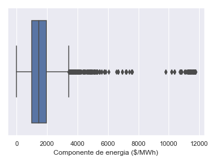

```python
ordereddf=df.sort_values(by='Componente de energia ($/MWh)', ascending=True)
sns.boxplot(x=ordereddf['Componente de energia ($/MWh)'])
```

```python
indexNameslow = ordereddf[ ordereddf['Componente de energia ($/MWh)'] < ordereddf['Componente de energia ($/MWh)'].quantile(0.25)].index
indexNameshigh = ordereddf[ ordereddf['Componente de energia ($/MWh)'] > ordereddf['Componente de energia ($/MWh)'].quantile(0.75)].index
```

```python
cleanerdata=ordereddf.drop(indexNameslow).drop(indexNameshigh)
```

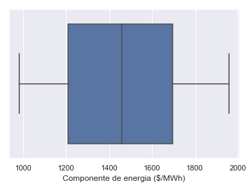

```python
sns.boxplot(x=cleanerdata['Componente de energia ($/MWh)'])
```

```python
#Dropping dates
cleanerdata.drop(['Fecha','Fecha_completa','Día','Mes','Año','Hora','Minuto'],axis=1, inplace=True)
```

```python
X_train, X_test, y_train, y_test = train_test_split(cleanerdata.loc[:, cleanerdata.columns != 'Componente de energia ($/MWh)'], cleanerdata['Componente de energia ($/MWh)'], test_size=0.2, random_state=1)
X_train, X_val, y_train, y_val = train_test_split(X_train, y_train, test_size=0.25, random_state=1)
```

```python
clf = SGDRegressor(max_iter=1000000, tol=10)
clf.fit(X_train, y_train)
```

```
SGDRegressor(alpha=0.0001, average=False, early_stopping=False, epsilon=0.1,
       eta0=0.01, fit_intercept=True, l1_ratio=0.15,
       learning_rate='invscaling', loss='squared_loss', max_iter=1000000,
       n_iter=None, n_iter_no_change=5, penalty='l2', power_t=0.25,
       random_state=None, shuffle=True, tol=10, validation_fraction=0.1,
       verbose=0, warm_start=False)
```

```python
prediction=clf.predict(X_train)
print(prediction, len(prediction), len(y_train))
```

```
[-3.54934371e+17 -4.20120972e+17 -4.55658022e+17 ... -3.91864378e+17
 -3.87304539e+17 -4.11731282e+17] 5674 5674
```

# Draft Code

```python
groupeddf=df.groupby(['Fecha']).mean()
```

```python
groupeddf
```

```python
cleandf=groupeddf.drop(['Día','Mes','Año','Hora','Minuto','Componente de energia ($/MWh)','Componente de congestion ($/MWh)','Componente de perdidas ($/MWh)','Demanda D. mod (MWh)','Demanda I. mod (MWh)','Brent','API2','HH','TdC'], axis=1)
```

```python
cleandf
```

```python
cuf.selecciona_fechas_demandas_DIARIO(df,'04/04/2019 0:00:00','05/04/2019 0:00:00','ACAPULCO')
```

```python
cuf.selecciona_fechas_demandas_HORARIO(df,'04/04/2019 0:00:00','05/04/2019 0:00:00','ACAPULCO')
```

```python
dfmapped=caf.mapping_nodes(df)
```

```python
dfmapped.head()
```

```python
Q1 = ordereddf.quantile(0.25)
Q3 = ordereddf.quantile(0.75)
IQR = Q3 - Q1
print(IQR)
```

```python
df=dfmapped.groupby(['Nodo o Region','Fecha'])
df=df.mean()
```

```python
a=(cleandf < (Q1 - 1.5 * IQR)) |(cleandf > (Q3 + 1.5 * IQR))
print(a)
```

```python
df
```

```python
ordereddf=df.sort_values(by='Precio', ascending=True)
sns.boxplot(x=ordereddf['Precio'])
```

```python
fig, ax = plt.subplots(figsize=(16,8))
ax.scatter(ordereddf['Precio'],ordereddf['Brent_pesos'])
ax.set_xlabel('Prices')
ax.set_ylabel('Brent_pesos')
plt.show()
```

```python
fig, ax = plt.subplots(figsize=(16,8))
ax.scatter(ordereddf['Precio'],ordereddf['Eolica'])
ax.set_xlabel('Prices')
ax.set_ylabel('Demands')
plt.show()
```

```python
fig, ax = plt.subplots(figsize=(16,8))
ax.scatter(ordereddf['Precio'],ordereddf['HH_pesos'])
ax.set_xlabel('Prices')
ax.set_ylabel('HH_pesos')
plt.show()
```

```python
fig, ax = plt.subplots(figsize=(16,8))
ax.scatter(ordereddf['Precio'],ordereddf['API2_pesos'])
ax.set_xlabel('Prices')
ax.set_ylabel('API2_pesos')
plt.show()
```

```python
ordereddf['Precio'].describe()
```

```python
print('indexNameslow\n',indexNameslow,'\nindexNameshigh\n',indexNameshigh)
```

```python
cleanerdata.describe()
```

```python
sns.boxplot(x=cleanerdata['Precio'])
```

```python
register_matplotlib_converters()
fig, ax = plt.subplots(figsize=(16,8))
ax.scatter(ordereddf['Precio'],ordereddf['Demanda total (MWh)'])
ax.set_xlabel('Prices')
ax.set_ylabel('Demands')
plt.show()
```

```python
register_matplotlib_converters()
fig, ax = plt.subplots(figsize=(16,8))
ax.scatter(cleanerdata['Precio'],cleanerdata['Demanda total (MWh)'])
ax.set_xlabel('Prices')
ax.set_ylabel('Demands')
plt.show()
```

```python
cleandf=cleanerdata.drop(['Componente de energia ($/MWh)','Demanda D. mod (MWh)','Demanda I. mod (MWh)','Brent','API2','HH','TdC'], axis=1)
```

```python
toclean=[]
for i in cleandf.columns:
    toclean.append(cleandf[a[i]==True].index)
print(toclean)
```

```python
for i in range(len(toclean)):
    cleandfplus=cleandf.drop(toclean[i])
print(cleandfplus.describe(),cleandfplus.info(),cleandfplus.head())
```

```python
cuf.selecciona_fechas_ENERGIA_DEMANDA_PRODUCCION_HORARIO(df,'01/02/2019 00:00:00','15/02/2019 00:00:00','MONTERREY')
```

## splitting data

```python
X_train.shape
```

```python
y_train.shape
```

```python
y_train.iloc[0]
```

```python
X_train[0:1][:]
```

```python
clf.predict(X_train[0:1])[0]
```

```python
cleandfplus[cleandfplus['Precio']==y_train.iloc[0]]
```

```python
X_train.loc[1544641]
```

```python
clf.predict(X_train)
```

```python
#tscv = TimeSeriesSplit(n_splits=5)
```

```python
#rint(tscv)
```

```python
indexNameslow = cleandf[ cleandf['Precio'] < cleandf['Precio'].quantile(0.25)].index
indexNameshigh = cleandf[ cleandf['Precio'] > cleandf['Precio'].quantile(0.75)].index
```

```python
sns.boxplot(x=cleandf['Precio'])
```

```python
cleanerdata=cleandf.drop(indexNameslow).drop(indexNameshigh)
sns.boxplot(x=cleanerdata['Precio'])
```

```python
X_train, X_test, y_train, y_test = train_test_split(cleanerdata.loc[:, cleanerdata.columns != 'Precio'], cleanerdata['Precio'], test_size=0.2, random_state=1)
X_train, X_val, y_train, y_val = train_test_split(X_train, y_train, test_size=0.25, random_state=1)
```

```python
clf = SGDRegressor(max_iter=1000000, tol=10)
clf.fit(X_train, y_train)
```

```python
cleanerdata
```

```python
clf.predict(X_train)
```